# Kursustilmeldinger

Christian Knudsen

2025-12-31

Vi analyserer her ialt 616 kurser fra vore kursustilmeldinger, der strækker sig fra 2021-01-26 11:30:00 til 2025-12-17 11:30:00

Det fører til sådan ca. 6101 bookinger, inklusive de der er endt på ventelisten.

**Hvad gør vi?**

Hver nat kl. 1 (UTC), kører tre scripts på GitHub. Gennem et api-kald til vores kalendersystem trækkes data på samtlige kurser fra 1. januar det aktuelle år, og 365 dage frem, i Datalabs kursuskalender. Kurserne har et ID-nummer, der sammenholdes med de kurser der tidligere er blevet hentet. De kurser der ikke allerede er gemt data for, og som ikke ligger i fremtiden, får gemt deres metadata.

Dernæst kører script nr. to. Det kigger på de kursus-ID’er der nu ligger i metadata registreringen. De sammenholdes med tilmedlingsdata der tidligerer er blevet gemt. Hvis kursus-ID’et ikke optræder dér, er det fordi det ikke har fået hentet tilmeldingsdata. De tilmeldingsdata hentes og saneres for at justere på strukturen. Et gæstimat på kønnet af deltageren foretages på baggrund af fornavnet, hvorefter data saneres for at fjerne personhenførbare data. Og så gemmes det.

Tredie script kører derefter. Det er det script der genererer denne side. Vi har med andre ord ret opdaterede data her.

I den aktuelle opsætning er det noget der tager ret lang tid ~45 minutter; robusthed fremfor tempo!

**Hvad mangler?**

1. Vi har gemt regneark med tilmeldingsdata i et års tid. Der er data vi kan bruge til at gæstimere kønnet på de tilmeldte. Og vi har også svar på de spørgsmål vi stiller dem. Det skal vi have konsolideret med de data vi henter ind her.
2. Vi har også gennem en længere periode automatisk indsamlet antallet af tilmeldinger, blandt andet mhp at lave vores observationslister, hvor vi ser på hvor fyldte kurserne er. Her er der også metadata der bør bruges til at berige de data vi har her.

Disse to berigelser er relativt enkle at lave. Største udfordring er forskellen i præcisionen af det rapporterede tilmeldingstidspunkt.

Data fra punkt 2 er tilføjet. Der mangler fortsat punkt 1 - regnearkene.

Den svære er at hægte de her data sammen med registreringen af deltagertallene. Det bør kunne lade sig gøre, men er ikke helt enkelt, hvis det ikke skal gøres manuelt.

Og så er vi begrænset af de data vi faktisk har gemt. Hvis ikke der er sat en kategori på der hedder “R” kan vi pt ikke se på kurset at det er et R-kursus. Eller - det kan vi godt, vi skal bare trække det ud fra beskrivelsen. Og “R” er ikke en specielt fantastisk søgeterm… Det finder vi nok også en løsning på.

Det har vi - men inden du drager alt for hårde konklusioner på det, bør vi nok lige trippeltjekke at det fungerer som det skal.

**Jeg synes der er noget der mangler?**

Hvis du har et spørgsmål der kan besvares med de data der er tilgængelige (og altså derfor med forbehold for de tre punkter nævnt ovenfor), kan det besvares. Formentlig ret hurtigt. Men det vil være fremmende for processen hvis jeg får spørgsmålet 15 minutter før du gerne vil have svaret. Så kast en mail, eller endnu bedre, smid et [issue på GitHub](https://github.com/KUBDatalab/kursus_data/issues/new) så fixer jeg det.

**Kan vi få svar på X?**

Formentlig, se ovenstående for hele to måder at få et svar (man kan selvfølgelig også selv downloade data fra https://github.com/KUBDatalab/kursus_data/tree/main/data og selv analysere).

Men. Der er grænser, for vi kan kun svare på ting som data understøtter svar på.

Vi har pt to tabeller.

Metadata med metadata for kurserne

```
## Rows: 1
## Columns: 17
## $ id                    <dbl> 4216775
## $ title                 <chr> "Åbent værksted i Labbet / drop in consultations…
## $ start                 <dttm> 2025-09-10 10:30:00
## $ created               <dttm> NA
## $ description           <chr> "<p>Having problems importing data? Or cleaning …
## $ location_name         <chr> "Library Lighthouse, Zone 3"
## $ campus_name           <chr> "KUB Nørre Campus, Nørre Allé 49, 2200 Københav…
## $ category_name         <chr> "datalab"
## $ seats                 <dbl> NA
## $ registration_open_at  <dttm> NA
## $ registration_close_at <dttm> NA
## $ physical_seats        <dbl> NA
## $ physical_seats_taken  <dbl> NA
## $ online_seats          <dbl> NA
## $ online_seats_taken    <dbl> NA
## $ seats_taken           <dbl> NA
## $ wait_list             <lgl> NA
```

og tilmeldingsdata for tilmeldingerne:

```
## Rows: 312
## Columns: 15
## $ event_id          <dbl> 4381177, 4381177, 4381177, 4381177, 4381177, 4381177…
## $ tilm_type         <chr> "registrants", "registrants", "registrants", "regist…
## $ last_name         <lgl> NA, NA, NA, NA, NA, NA, NA, NA, NA, NA, NA, NA, NA, …
## $ booking_id        <dbl> 4860707, 4860707, 4860707, 4860707, 4860707, 4860707…
## $ registration_type <chr> "in-person", "in-person", "in-person", "in-person", …
## $ first_name        <lgl> FALSE, FALSE, FALSE, FALSE, FALSE, FALSE, FALSE, FAL…
## $ barcode           <lgl> NA, NA, NA, NA, NA, NA, NA, NA, NA, NA, NA, NA, NA, …
## $ phone             <lgl> NA, NA, NA, NA, NA, NA, NA, NA, NA, NA, NA, NA, NA, …
## $ email             <chr> "bb186e194ef389b43fd984c7a6588eba", "bb186e194ef389b…
## $ registered_date   <dttm> 2025-06-03 09:16:27, 2025-06-03 09:16:27, 2025-06-0…
## $ attendance        <chr> "-", "-", "-", "-", "-", "-", "-", "-", "-", "-", "-…
## $ qid               <dbl> 15967, 15968, 15969, 15970, 21065, 15973, 15972, 159…
## $ question          <chr> "Faculty", "Programme / Line of study (If not applic…
## $ answer            <chr> "Faculty of Social Sciences (UCPH)", "Psychology", "…
## $ køn               <lgl> FALSE, FALSE, FALSE, FALSE, FALSE, FALSE, FALSE, FAL…
```

Eventid for tilmeldingen hænger sammen med id for kurset. Og first_name indeholder et gæstimat af kønnet baseret på fornavnet. Ja, det er noget sjusk, og skal nok blive rettet. Under alle omstændigheder, er det en logisk værdi som svar på spørgsmålet “gætter vi på at deltageren har det rigtige køn?”. TRUE for kvinder, FALSE for mænd. Så hvis du vil vide om der er forskel på det tidspunkt på dagen de studerende tilmelder sig når kurset har kategorien “english” kontra tidspunktet når det er kategorien “Python”, så kan vi svare på det. Vær dog opmærksom på at kategorierne i kursusmetadata ikke er bedre end dem du selv har lagt ind…

# Og så til tallene!

Udvikling i antal kurser over årene:

| år | antal |
| --- | --- |
| 2021 | 110 |
| 2022 | 117 |
| 2023 | 128 |
| 2024 | 130 |
| 2025 | 131 |

Eller, grafisk fremstillet:

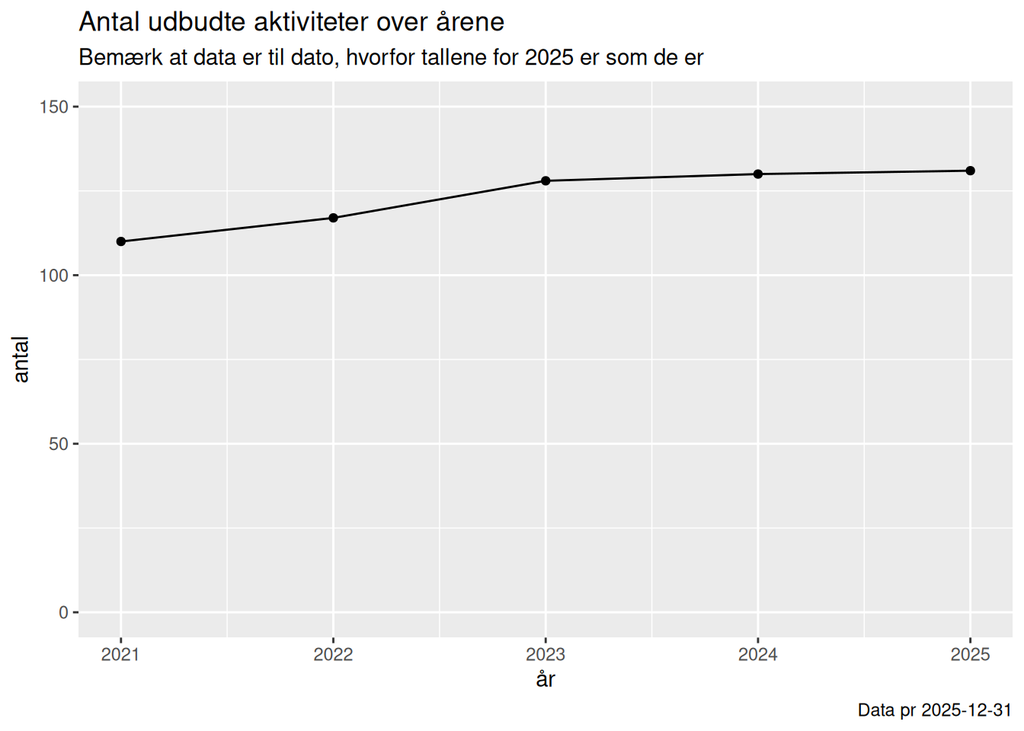

## Antal tilmeldte over årene

[output not shown]

| år | registrants | waitlist |
| --- | --- | --- |
| 2021 | 915 | 162 |
| 2022 | 815 | 99 |
| 2023 | 936 | 70 |
| 2024 | 1197 | 185 |
| 2025 | 1408 | 314 |

Registrants er de der har fået plads på kurset. Waitlist er de der er på venteliste.

## Antal aktiviteter i kalenderen over tid - opdelt på måned

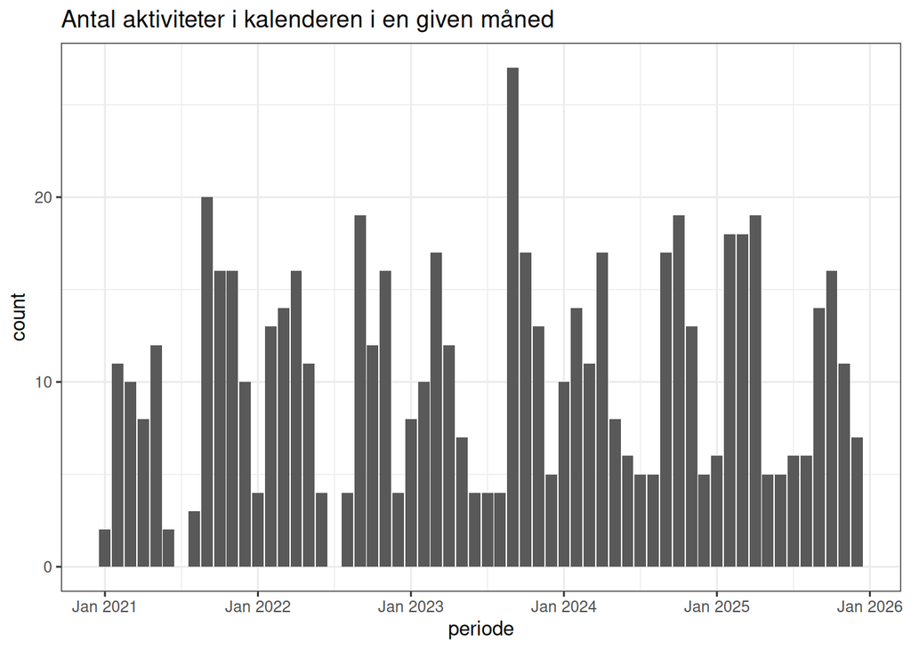

## Kønsfordelingen

| år | hun | han | andel_hun | andel_han |
| --- | --- | --- | --- | --- |
| 2021 | 73 | 41 | 0.6403509 | 0.3596491 |
| 2022 | 576 | 214 | 0.7291139 | 0.2708861 |
| 2023 | 467 | 201 | 0.6991018 | 0.3008982 |
| 2024 | 648 | 244 | 0.7264574 | 0.2735426 |
| 2025 | 914 | 384 | 0.7041602 | 0.2958398 |
| total | 2678 | 1084 | 0.7118554 | 0.2881446 |

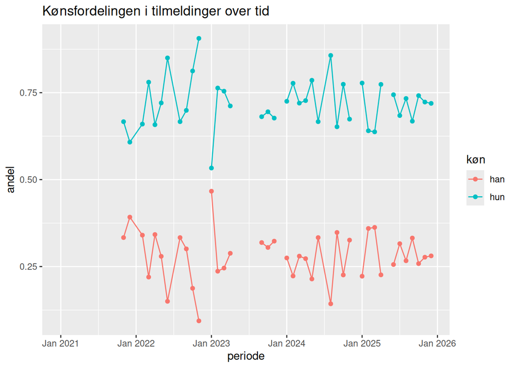

Inden der drages for håndfaste konklusioner om en skæv kønsfordeling - som dog næppe er af en karakter vi behøver tage alvorligt, skal der dog foretages en chi-i-anden test hvor vi sammenligner med kønsfordelingen på KU.

De sidste tal der er til rådighed der, er fra 2023. Der var ialt 22917 fuldtidsstuderende kvinder og 13611 fuldtidsstuderende mænd. Svarende til en kønsfordeling på 37.2618265 % af det underrepræsenterede køn. Den relevante sammenligning er derfor med vores 2023 tal:

```
##
##  Pearson's Chi-squared test with Yates' continuity correction
##
## data:  .
## X-squared = 14.149, df = 1, p-value = 0.0001689
```

chi-i-anden testen svarer på om der er forskel på kønsfordelingen blandt indskrevne studerende på KU, og på vores kurser, og resultatet er, at underrepræsentationen af mænd på vores kurser er statistisk signifikant. Da kønsfordelingen på vores kurser ikke er blevet bedre siden 2023, og der ikke er nogen grund til at tro at den er blevet mere lige på KU som helhed, er der god grund til at tro at problemet fortsat eksisterer.

Da det underrepræsenterede køn er mænd, er det ikke noget vi har i sinde at gøre noget ved.

En mulig forklaring kan være at vi ikke tiltrækker særligt mange studerende fra de uddannelser hvor kønsfordelingen stadig er nogenlunde lige, eller fra de ganske få fag hvor mændene er i overtal: Efterspørgslen på vores kursustilbud blandt studerende på eksempelvis datalog må forventes at være begrænset. Det betyder at vi primært rekrutterer deltagere på de fag hvor den strukturelle køndiskrimination betyder at mænd er endnu mere underrepræsenterede end de er på KU som helhed. Og dermed at den relevante sammenligning ikke er den samlede KU-population, men en delmængde af fakulteterne..

## tilmeldinger - og ventelister, pr. kursus.

der er mange…

Så her er et udvalg

| id | title | start | registrants | waitlist | seats | andel_fyldt |
| --- | --- | --- | --- | --- | --- | --- |
| 4216789 | Åbent værksted i Labbet / drop in consultations at KUB Datalab | 2025-12-17 11:30:00 | 0 | 0 | NA | NA |
| 4455591 | R for Absolute Beginners (Christmas edition) | 2025-12-16 12:00:00 | 30 | 18 | 30 | 1.00 |
| 4459887 | Python for Absolute Beginners pt. 2 | 2025-12-15 08:30:00 | 18 | 0 | 25 | 0.72 |
| 4216788 | Åbent værksted i Labbet / drop in consultations at KUB Datalab | 2025-12-10 11:30:00 | 0 | 0 | NA | NA |
| 4459886 | Python for Absolute Beginners pt. 1 | 2025-12-08 08:30:00 | 25 | 3 | 25 | 1.00 |
| 4216787 | Åbent værksted i Labbet / drop in consultations at KUB Datalab | 2025-12-03 11:30:00 | 0 | 0 | NA | NA |

## Antal tilmeldinger pr. kursus pr år

For folk der har svært ved at læse tabeller:

0 betyder ikke nødvendigvis at kurset har været en fiasko. Det kan også bare, helt enkelt, betyde at kurset første gang blev udbudt i 2023. Og derfor var der 0 deltagere på det endnu ikke-eksisterende kursus i 2022.

| 2024 | 2021 | 2023 | 2025 | 2022 |
| --- | --- | --- | --- | --- |
| Python for Absolute Beginners pt. 1 |  |  |  |  |
| 146 | 0 | 41 | 222 | 0 |
| Python for Absolute Beginners pt. 2 |  |  |  |  |
| 129 | 0 | 37 | 186 | 0 |
| R for Absolute Beginners |  |  |  |  |
| 209 | 36 | 128 | 173 | 50 |
| R for absolutte nybegyndere |  |  |  |  |
| 55 | 0 | 0 | 133 | 0 |
| R for Absolute Beginners - ONLINE |  |  |  |  |
| 94 | 17 | 133 | 90 | 40 |
| Explorative data analysis with R |  |  |  |  |
| 18 | 0 | 5 | 69 | 0 |
| Python and Pandas - Getting Started with Data Analysis |  |  |  |  |
| 24 | 0 | 0 | 68 | 0 |
| NVivo for Absolute Beginners - in English |  |  |  |  |
| 0 | 0 | 0 | 65 | 0 |
| NVivo - Cases and Classification in Interview Data |  |  |  |  |
| 30 | 0 | 0 | 58 | 0 |
| Introduction to visualizing with ggplot2 in R |  |  |  |  |
| 3 | 0 | 10 | 50 | 0 |
| NVivo for Absolute Beginners |  |  |  |  |
| 28 | 0 | 0 | 43 | 0 |
| NVivo for absolutte begyndere |  |  |  |  |
| 38 | 0 | 0 | 38 | 0 |
| R and APIs - Statistics Denmark |  |  |  |  |
| 10 | 0 | 11 | 36 | 6 |
| R for Absolute Beginners (Christmas edition) |  |  |  |  |
| 0 | 0 | 0 | 30 | 0 |
| From digital photos to 3D models - photogrammetry with Metashape |  |  |  |  |
| 0 | 0 | 0 | 20 | 0 |

[output cut: 292 more lines]

## Gennemsnitlig belægningsgrad

Altså - hvor stor en andel af pladserne der udbydes bliver fyldt med tilmeldinger. Her skal vi nok fjerne de åbne værksteder først. Samlet tabel pr år, opdeling pr måned.

Andel af pladser udbudt, fyldt

| År | Belægningsgrad |
| --- | --- |
| 2021 | 56% |
| 2022 | 57% |
| 2023 | 54% |
| 2024 | 66% |
| 2025 | 71% |

En række digital humaniora aktiviteter, der har været annonceret, men hvor tilmelding er foregået på anden vis, har ikke registrerede tilmeldinger. Tilsvarende er 'Åbent værksted' fjernet fra oversigten, da der her heller ikke er tilmelding.

## Udvikling i belægningsgrad

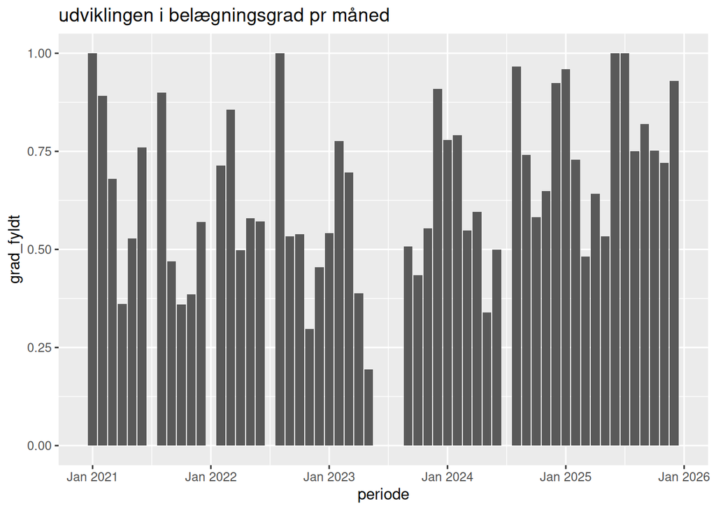

## Kategorier

De kategorier der optræder i data.

Vi skal stadig overveje at finde en måde at tildele en overordnet kategori på software. Der er store mangler i registreringerne, så der skal tænkes…

Nu starter vi med at tælle hvad vi har.

Antal kursusaktiviteter fordelt på kategori

| Kategori | Antal |
| --- | --- |
| analysis | 451 |
| arcgis | 5 |
| cleaning | 284 |
| datalab | 616 |
| english | 382 |
| excel | 42 |
| harvesting | 226 |
| metashape | 7 |
| nvivo | 98 |
| online course | 8 |
| openrefine | 16 |
| orange | 20 |
| python | 130 |
| r | 102 |
| regex | 10 |
| sql | 4 |
| visualisation | 246 |
| vosviewer | 1 |
| voyant | 11 |
| værksted | 213 |

Bemærk at kategoriene kommer fra tilmeldingssystemet, og brugen af labels på kursusaktiviteter er meget ujævn

Antal aktiviteter pr kategori - fordelt på år:

Antal kursusaktiviteter fordelt på kategori og år

| Kategori | 2021 | 2022 | 2023 | 2024 | 2025 |
| --- | --- | --- | --- | --- | --- |
| analysis | 56 | 63 | 107 | 113 | 112 |
| arcgis | 5 | 0 | 0 | 0 | 0 |
| cleaning | 30 | 35 | 70 | 73 | 76 |
| datalab | 110 | 117 | 128 | 130 | 131 |
| english | 50 | 76 | 67 | 105 | 84 |
| excel | 17 | 7 | 10 | 4 | 4 |
| harvesting | 20 | 26 | 60 | 60 | 60 |
| nvivo | 21 | 26 | 20 | 17 | 14 |
| online course | 1 | 1 | 3 | 3 | 0 |
| openrefine | 11 | 1 | 2 | 2 | 0 |
| python | 31 | 25 | 19 | 26 | 29 |
| r | 16 | 13 | 19 | 26 | 28 |
| regex | 3 | 1 | 2 | 3 | 1 |
| sql | 2 | 0 | 2 | 0 | 0 |
| visualisation | 18 | 30 | 63 | 68 | 67 |
| vosviewer | 1 | 0 | 0 | 0 | 0 |
| voyant | 2 | 1 | 3 | 3 | 2 |
| værksted | 17 | 43 | 51 | 52 | 50 |
| metashape | 0 | 0 | 2 | 3 | 2 |
| orange | 0 | 0 | 7 | 9 | 4 |

Bemærk at kategorierne kommer fra kursustilmeldingssystemet, hvor brugen af kategorier er ret ujævn. De er derfor beriget ved en automatiseret proces - som bør kvalitetstjekkes. Bemærk også at et typisk kursus har mere end en kategori.

Brugen af kategorier i kalendersystemet er ret ujævn. Så der er tilføjet kategorier pr. automatik. Det lader fortsat en smule tilbage at ønske. Men vi er tæt på nu.

## Belægningsgrad pr. kategori pr år.

[output not shown]

Belægningsgrad - fordelt på kategori og år

| category_name | 2021 | 2022 | 2023 | 2024 | 2025 |
| --- | --- | --- | --- | --- | --- |
| analysis | 0.6438613 | 0.6355353 | 0.6115108 | 0.6869340 | 0.7777082 |
| arcgis | 0.3600000 | 0.0000000 | 0.0000000 | 0.0000000 | 0.0000000 |
| cleaning | 0.5404930 | 0.6225681 | 0.6958333 | 0.7001795 | 0.8017884 |
| datalab | 0.5586081 | 0.5731364 | 0.5426087 | 0.6562500 | 0.7113246 |
| english | 0.5389908 | 0.6040172 | 0.6359788 | 0.6534653 | 0.7493622 |
| excel | 0.4070081 | 0.4924242 | 0.5555556 | 0.3617021 | 0.6800000 |
| harvesting | 0.7041565 | 0.3064516 | 0.3666667 | 0.5714286 | 0.4476744 |
| nvivo | 0.5725338 | 0.6161616 | 0.5288270 | 0.5910931 | 0.6331522 |
| online course | 0.2000000 | 0.9000000 | 0.3500000 | 0.4266667 | 0.0000000 |
| openrefine | 0.2260870 | 0.1000000 | 0.4142857 | 0.0000000 | 0.0000000 |
| python | 0.5871795 | 0.4728682 | 0.4577778 | 0.7422868 | 0.7230114 |
| r | 0.7777778 | 0.6700680 | 0.6551020 | 0.6479100 | 0.7770535 |
| regex | 0.6296296 | 0.8000000 | 0.3555556 | 0.6500000 | 0.2272727 |
| sql | 0.2500000 | 0.0000000 | 0.6400000 | 0.0000000 | 0.0000000 |
| visualisation | 0.6375839 | 0.4957983 | 0.3750000 | 0.4761905 | 0.5207101 |
| vosviewer | 0.8125000 | 0.0000000 | 0.0000000 | 0.0000000 | 0.0000000 |
| voyant | 0.3500000 | 0.2666667 | 0.3600000 | 0.8750000 | 0.7083333 |
| metashape | 0.0000000 | 0.0000000 | 0.7272727 | 1.0000000 | 0.8333333 |
| orange | 0.0000000 | 0.0000000 | 0.4000000 | 0.4761905 | 0.5833333 |
| værksted | 0.0000000 | 0.0000000 | 0.0000000 | 1.0000000 | 0.0000000 |

Der bør nok forskes i hvad der sker med værkstederne - der er et år hvor der åbenbart har været en tilmelding.

## og grafisk

[output not shown]

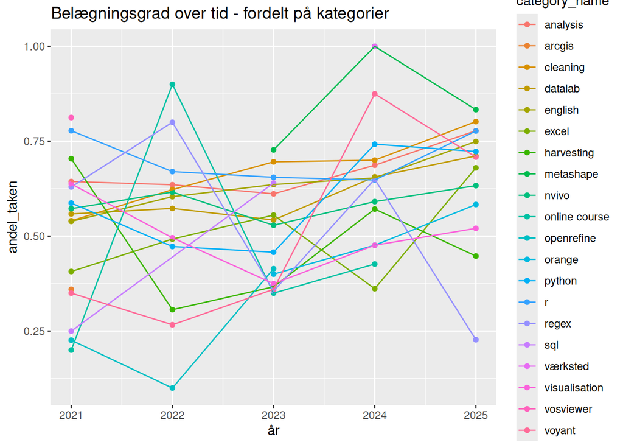

Gir det mening? Næh.

[output not shown]

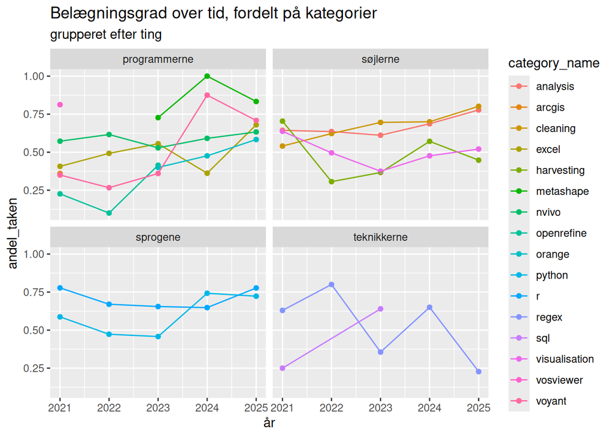

Det blev det ikke nødvendigvis mere klart af.

## Belægningsgrad pr. kategori pr år

Andel af pladser udbudt, fyldt

| 2021 | 2022 | 2023 | 2024 | 2025 |
| --- | --- | --- | --- | --- |
| analysis |  |  |  |  |
| 64% | 64% | 61% | 69% | 78% |
| arcgis |  |  |  |  |
| 36% | 0% | 0% | 0% | 0% |
| cleaning |  |  |  |  |
| 54% | 62% | 70% | 70% | 80% |
| datalab |  |  |  |  |
| 56% | 57% | 54% | 66% | 71% |
| english |  |  |  |  |
| 54% | 60% | 64% | 65% | 75% |
| excel |  |  |  |  |
| 41% | 49% | 56% | 36% | 68% |
| harvesting |  |  |  |  |
| 70% | 31% | 37% | 57% | 45% |
| metashape |  |  |  |  |
| 0% | 0% | 73% | 100% | 83% |
| nvivo |  |  |  |  |
| 57% | 62% | 53% | 59% | 63% |
| online course |  |  |  |  |
| 20% | 90% | 35% | 43% | 0% |
| openrefine |  |  |  |  |
| 23% | 10% | 41% | 0% | 0% |
| orange |  |  |  |  |
| 0% | 0% | 40% | 48% | 58% |
| python |  |  |  |  |
| 59% | 47% | 46% | 74% | 72% |
| r |  |  |  |  |
| 78% | 67% | 66% | 65% | 78% |
| regex |  |  |  |  |
| 63% | 80% | 36% | 65% | 23% |
| sql |  |  |  |  |
| 25% | 0% | 64% | 0% | 0% |
| visualisation |  |  |  |  |
| 64% | 50% | 38% | 48% | 52% |
| vosviewer |  |  |  |  |
| 81% | 0% | 0% | 0% | 0% |
| voyant |  |  |  |  |
| 35% | 27% | 36% | 88% | 71% |
| værksted |  |  |  |  |
| 0% | 0% | 0% | 100% | 0% |

MIDLERTIDIG FODNOTE: En række digital humaniora aktiviteter, der har været annonceret, men hvor tilmelding er foregået på anden vis, har ikke registrerede tilmeldinger. Tilsvarende er 'Åbent værksted' fjernet fra oversigten, da der her heller ikke er tilmelding.

#### sprogene

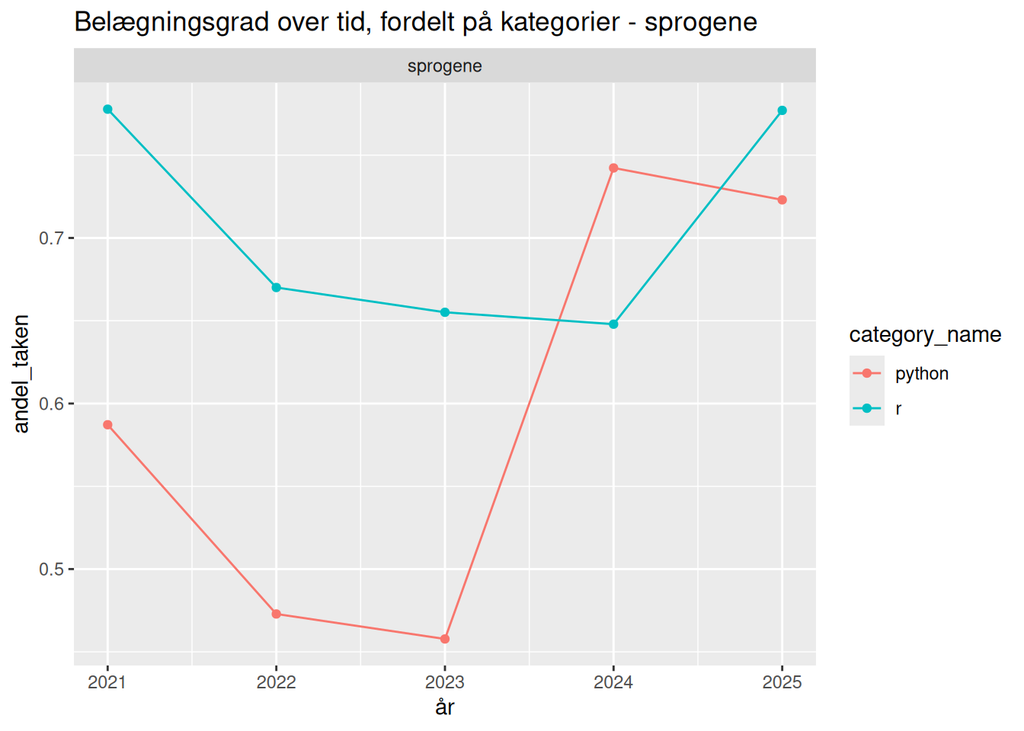

#### programmerne

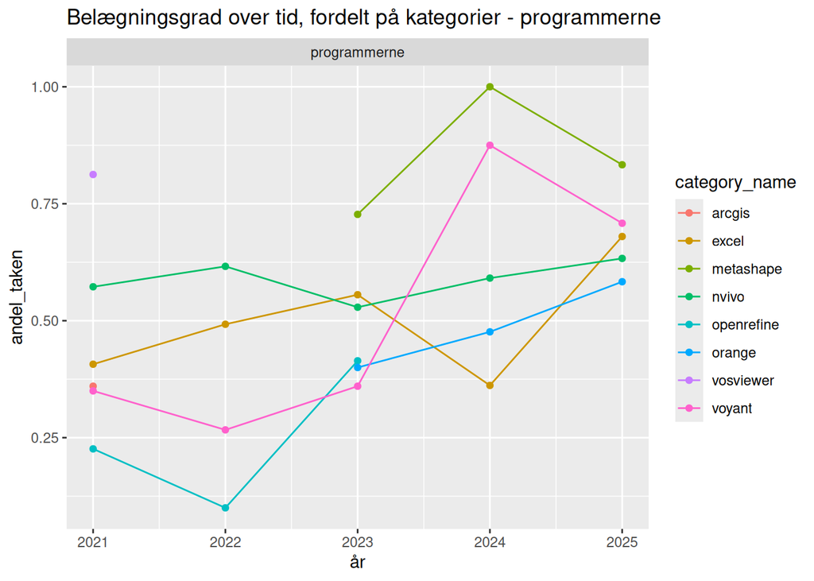

#### teknikkerne

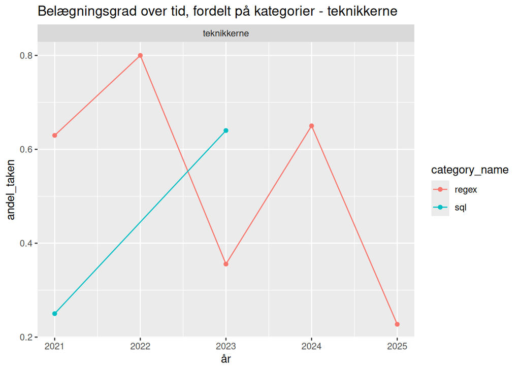

#### søjlerne

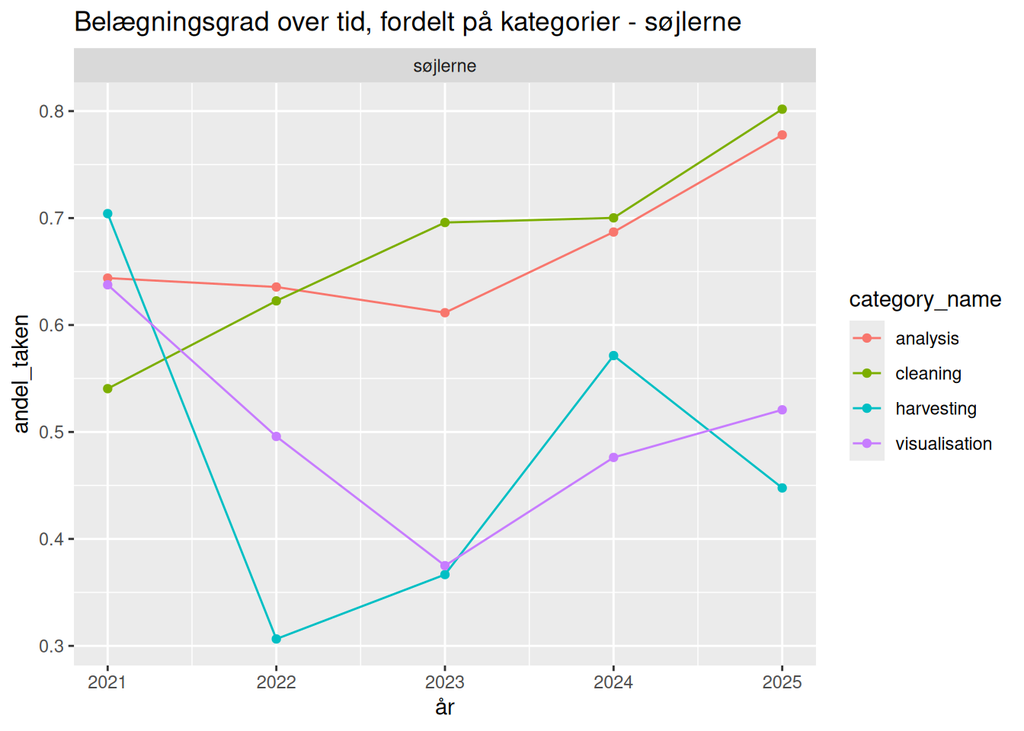

## tilmeldinger - inklusive ventelister som fkt af år og kategori

[output not shown]

```
## # A tibble: 78 × 6
##       år category_name tilmeldte venteliste pladser andel
##    <dbl> <chr>             <int>      <int>   <dbl> <dbl>
##  1  2021 analysis            687        129    1067 0.644
##  2  2021 arcgis               18          0      50 0.36
##  3  2021 cleaning            307         49     568 0.540
##  4  2021 datalab             915        162    1638 0.559
##  5  2021 english             470        137     872 0.539
##  6  2021 excel               151         18     371 0.407
##  7  2021 harvesting          288         57     409 0.704
##  8  2021 nvivo               296          1     517 0.573
##  9  2021 online course         5          0      25 0.2
## 10  2021 openrefine           52          0     230 0.226
## # ℹ 68 more rows
```

## udvikling i tilmeldinger som funktion af tid.

Nogen særlige ønsker til behandlingen af ventelistetilmeldinger?

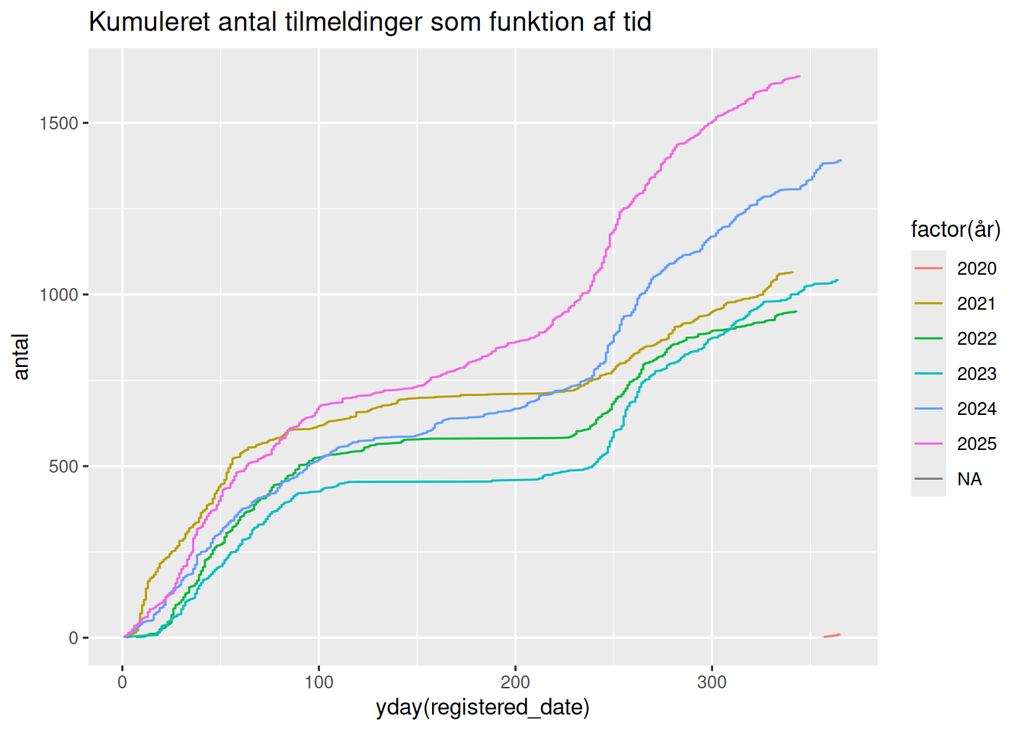

## Hvor kommer de fra?

Vi har i begrænset omfang viden om deres faglige baggrund. Og der mangler at blive tilføjet diverse regneark.

```
## # A tibble: 8 × 3
## # Groups:   year(registered_date) [1]
##   `year(registered_date)` answer                                            n
##                     <dbl> <chr>                                         <int>
## 1                    2025 Faculty of Health and Medical Sciences (UCPH)   202
## 2                    2025 Faculty of Humanities (UCPH)                    107
## 3                    2025 Faculty of Law (UCPH)                            13
## 4                    2025 Faculty of Science (UCPH)                       341
## 5                    2025 Faculty of Social Sciences (UCPH)               211
## 6                    2025 Faculty of Theology (UCPH)                        3
## 7                    2025 Not related to any university                     6
## 8                    2025 Other university than UCPH                        3
```

## Sammenligning mellem kursuskalendere

Belægningsgrader og sådan. Der er vi jo nødt til at have en ide om hvordan det ser ud for andre kursuskalendere.

```
## ℹ Using "','" as decimal and "'.'" as grouping mark. Use `read_delim()` for more control.
```

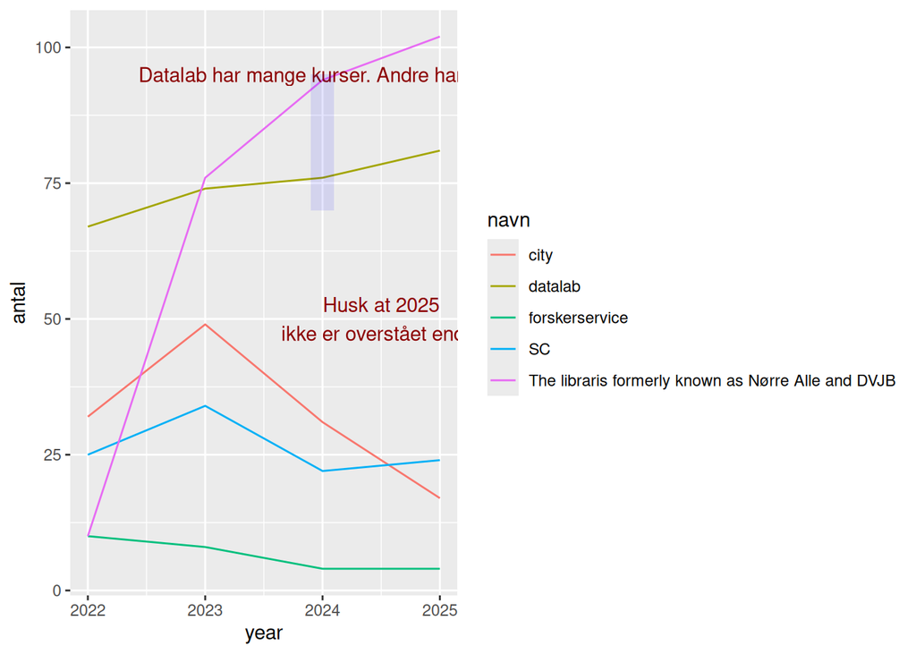

Hvordan med belægningsgraden? Klarer vi os virkelig så ringe?

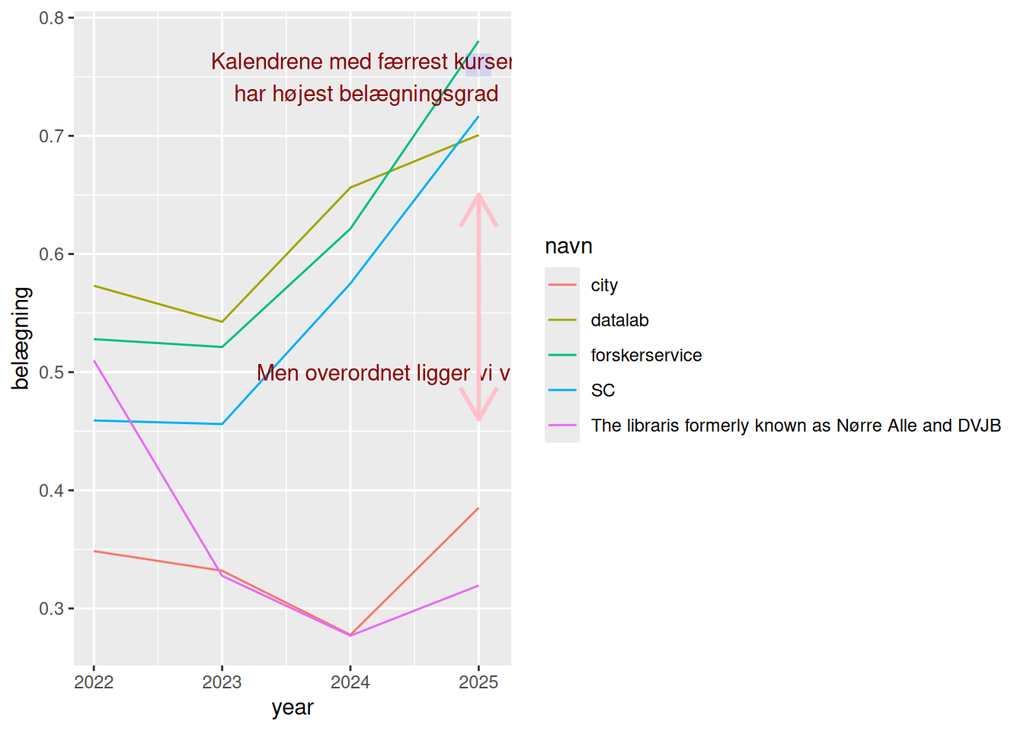

```
## <ggplot2::labels> List of 1
##  $ title: chr "belægningsgrad sammenlignet over tid mellem 5 kalendere"
```

Efterspørgslen:

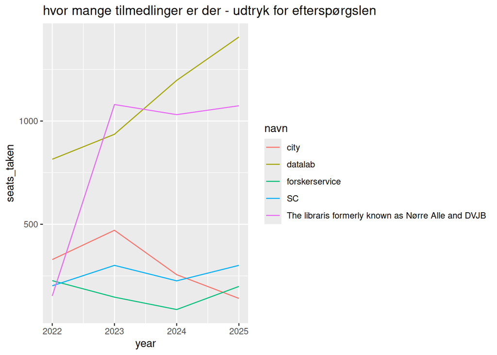

gennemsnitligt antal deltagere

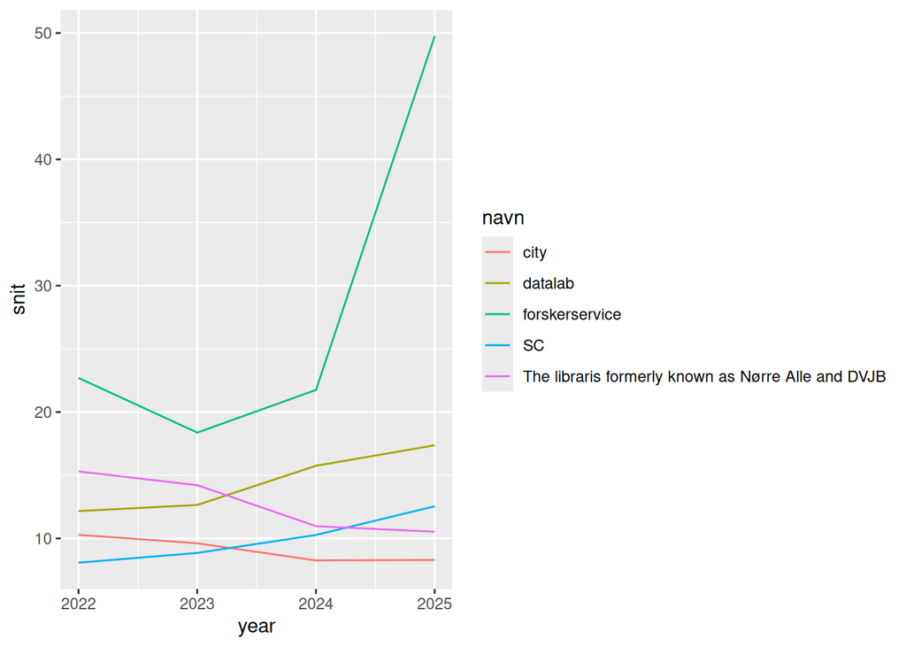

Jamen udbyder vi så ikke bare for mange pladser?

Måske, men det er der vist andre der også gør.

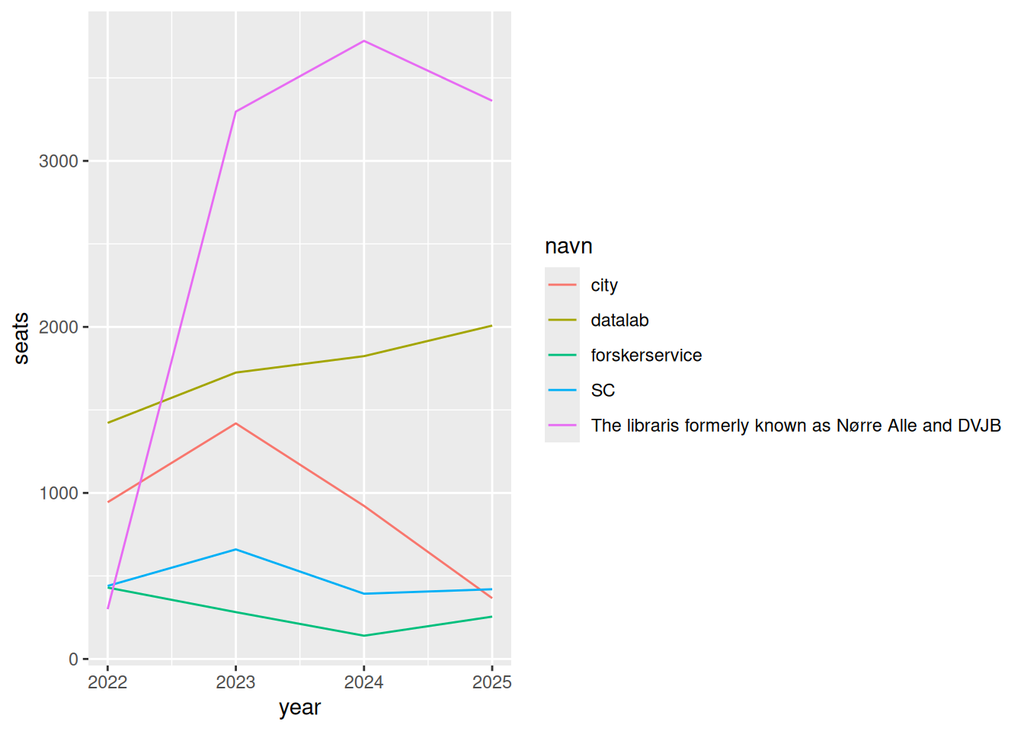